# A5

```r
# Test LotConfig and Quality with nested f-tests because some of their factors are not in the lowest cp model given by regsubsets
smallModel1 = lm(Price~LotFrontage+LotArea+factor(Quality)+YearBuilt+ExteriorQ+BasementSF+GroundSF+KitchenQ+Fireplaces+GarageSF+I(WoodDeckSF+OpenPorchSF+EnclosedPorchSF+ScreenPorchSF), data=AllData3)
fullModel1 = lm(Price~LotFrontage+LotArea+LotConfig+factor(Quality)+YearBuilt+ExteriorQ+BasementSF+GroundSF+KitchenQ+Fireplaces+GarageSF+I(WoodDeckSF+OpenPorchSF+EnclosedPorchSF+ScreenPorchSF), data=AllData3)

anova(fullModel1, smallModel1)
```

|  | Res.Df | RSS | Df | Sum of Sq | F | Pr(>F) |
| --- | --- | --- | --- | --- | --- | --- |
| 1 | 571 | 345062.0 | NA | NA | NA | NA |
| 2 | 575 | 348806.1 | -4 | -3744.09 | 1.548906 | 0.1865938 |

```r
# Based on the nested f-test, adding LotConfig does not significantly improve the fit of the model.
```

```r
smallModel2 = lm(Price~LotFrontage+LotArea+YearBuilt+ExteriorQ+BasementSF+GroundSF+KitchenQ+Fireplaces+GarageSF+I(WoodDeckSF+OpenPorchSF+EnclosedPorchSF+ScreenPorchSF), data=AllData3)
fullModel2 = lm(Price~LotFrontage+LotArea+factor(Quality)+YearBuilt+ExteriorQ+BasementSF+GroundSF+KitchenQ+Fireplaces+GarageSF+I(WoodDeckSF+OpenPorchSF+EnclosedPorchSF+ScreenPorchSF), data=AllData3)

anova(fullModel2, smallModel2)
```

|  | Res.Df | RSS | Df | Sum of Sq | F | Pr(>F) |
| --- | --- | --- | --- | --- | --- | --- |
| 1 | 575 | 348806.1 | NA | NA | NA | NA |
| 2 | 584 | 434713.8 | -9 | -85907.68 | 15.73523 | 4.148445e-23 |

regsubsets and nested-f test

```r
fullFancyModel3 = lm(Price~LotFrontage+LotArea+factor(Quality)+YearBuilt+ExteriorQ+BasementSF+GroundSF+KitchenQ+Fireplaces+GarageSF+I(WoodDeckSF+OpenPorchSF+EnclosedPorchSF+ScreenPorchSF), data=AllData3)

summary(fullFancyModel3)
```

```
##
## Call:
## lm(formula = Price ~ LotFrontage + LotArea + factor(Quality) +
##     YearBuilt + ExteriorQ + BasementSF + GroundSF + KitchenQ +
##     Fireplaces + GarageSF + I(WoodDeckSF + OpenPorchSF + EnclosedPorchSF +
##     ScreenPorchSF), data = AllData3)
##
## Residuals:
##      Min       1Q   Median       3Q      Max
## -129.370  -14.210   -0.053   12.437  108.889
##
## Coefficients:
##                                                                 Estimate
## (Intercept)                                                   -7.504e+02
## LotFrontage                                                    1.037e-01
## LotArea                                                        5.319e-04
## factor(Quality)2                                               2.207e+01
## factor(Quality)3                                               5.442e+01
## factor(Quality)4                                               5.352e+01
## factor(Quality)5                                               5.798e+01
## factor(Quality)6                                               6.818e+01
## factor(Quality)7                                               8.275e+01
## factor(Quality)8                                               1.111e+02
## factor(Quality)9                                               9.212e+01
## factor(Quality)10                                              1.541e+02
## YearBuilt                                                      4.229e-01
## ExteriorQFa                                                   -6.145e+01
## ExteriorQGd                                                   -5.301e+01
## ExteriorQTA                                                   -5.697e+01
## BasementSF                                                     2.015e-02
## GroundSF                                                       3.961e-02
## KitchenQFa                                                    -5.683e+01
## KitchenQGd                                                    -4.206e+01
## KitchenQPo                                                    -4.200e+01
## KitchenQTA                                                    -4.800e+01
## Fireplaces                                                     1.071e+01
## GarageSF                                                       3.522e-02
## I(WoodDeckSF + OpenPorchSF + EnclosedPorchSF + ScreenPorchSF)  2.596e-02
##                                                               Std. Error
## (Intercept)                                                    9.722e+01
```

[output cut: 67 more lines]

```
## BasementSF                                                    1.29e-08 ***
## GroundSF                                                       < 2e-16 ***
## KitchenQFa                                                    1.79e-09 ***
## KitchenQGd                                                    2.85e-14 ***
## KitchenQPo                                                    0.098817 .
## KitchenQTA                                                    9.96e-16 ***
## Fireplaces                                                    7.59e-08 ***
## GarageSF                                                      1.78e-08 ***
## I(WoodDeckSF + OpenPorchSF + EnclosedPorchSF + ScreenPorchSF) 0.000148 ***
## ---
## Signif. codes:  0 '***' 0.001 '**' 0.01 '*' 0.05 '.' 0.1 ' ' 1
##
## Residual standard error: 24.63 on 575 degrees of freedom
## Multiple R-squared:  0.8983, Adjusted R-squared:  0.8941
## F-statistic: 211.6 on 24 and 575 DF,  p-value: < 2.2e-16
```

```r
finalFancyModel = fullFancyModel3
```

Now, visual inspections of residuals will be performed, to see if the model works reasonably well.

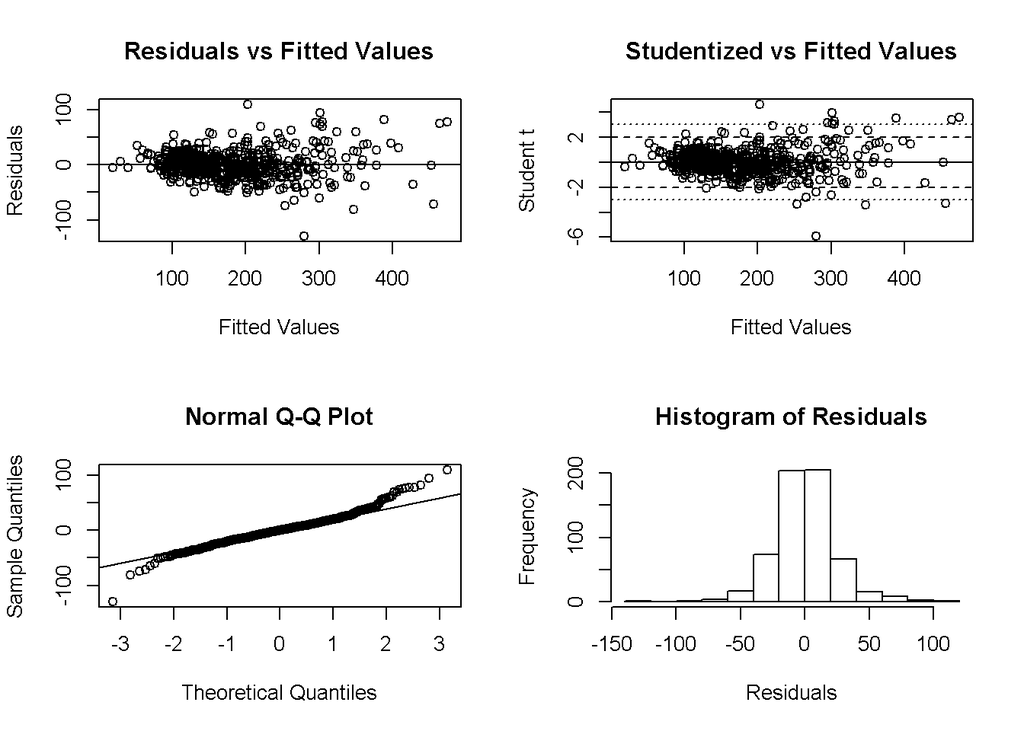

```r
r_student <- rstudent(fullFancyModel3)

par(mfrow=c(2,2))
plot(fullFancyModel3$residuals~fullFancyModel3$fitted.values, main="Residuals vs Fitted Values", xlab="Fitted Values", ylab="Residuals")
abline(0,0)
plot(r_student ~ fullFancyModel3$fitted.values,  main="Studentized vs Fitted Values", xlab="Fitted Values", ylab="Student t")
abline(0,0)
abline(2,0, lty=2)
abline(-2,0, lty=2)
abline(3,0, lty=3)
abline(-3,0, lty=3)
qqnorm(fullFancyModel3$residuals)
qqline(fullFancyModel3$residuals)
hist(fullFancyModel3$residuals, breaks=12,main="Histogram of Residuals", xlab="Residuals")
```

The distribution of the error is centered at zero. In other words, points are randomly scattered above and below the line. This can be confirmed by Residuals vs Fitted Plot and the histogram of residuals.

Basically, the residual vs fitted plot lets us have an idea about the properties of constant variance. In our model, there is no obvious pattern in our residual vs fitted plot, yet there is little fan-shaped distribution. However, we suppose that this distribution is reasonably accepted in the context of our model.

A couple of residuals are away from the center, i.e. more than 3 t-values from the mean. However, we were not able to simply get rid of outliers, in that there are several cases as displayed by the studentized vs fitted plot, and no clear reason to exclude them.

Our conclusion for this residual analysis is that the distribution of the error terms are close to normal distribution, and it doesn’t seem that we need any transformation to address any issue related a biased distribution of the residuals.

** PART 8 **

Fancy Model Cross-Validation

```r
priceFit = predict(finalFancyModel, newdata=AmesTest12)
holdoutres = AmesTest12$Price - priceFit

summary(holdoutres)
```

```
##     Min.  1st Qu.   Median     Mean  3rd Qu.     Max.
## -85.7964 -14.3242   1.0495   0.4214  15.1374  93.5852
```

```r
sd(holdoutres)
```

```
## [1] 26.05098
```

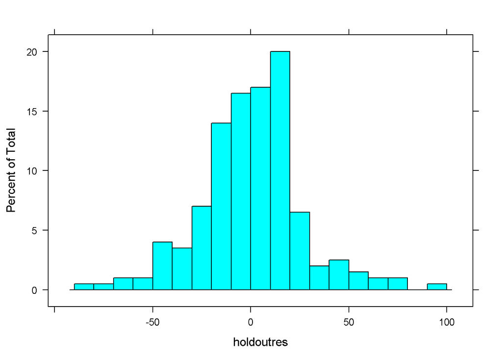

```r
histogram(holdoutres, breaks=15)
```

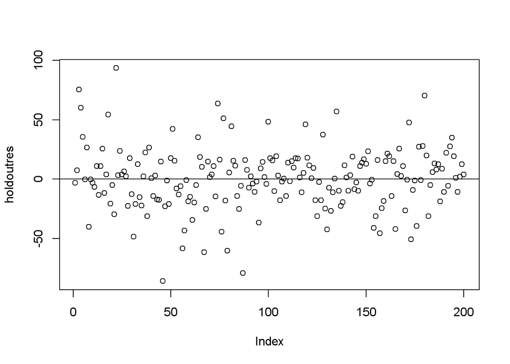

```r
plot(holdoutres)
abline(0,0)
```

```r
corr = cor(AmesTest12$Price, priceFit)
corr
```

```
## [1] 0.9461979
```

```r
summary(finalFancyModel)$r.squared-corr^2
```

```
## [1] 0.003010485
```

Basic Model Cross-Validation

```r
fitPrice = predict(BasicModel, newdata=AmesTest12)
holdoutresid = AmesTest12$Price - fitPrice

summary(holdoutresid)
```

```
##     Min.  1st Qu.   Median     Mean  3rd Qu.     Max.
## -110.967  -15.094    1.891    1.475   17.897   97.423
```

```r
sd(holdoutresid)
```

```
## [1] 28.67133
```

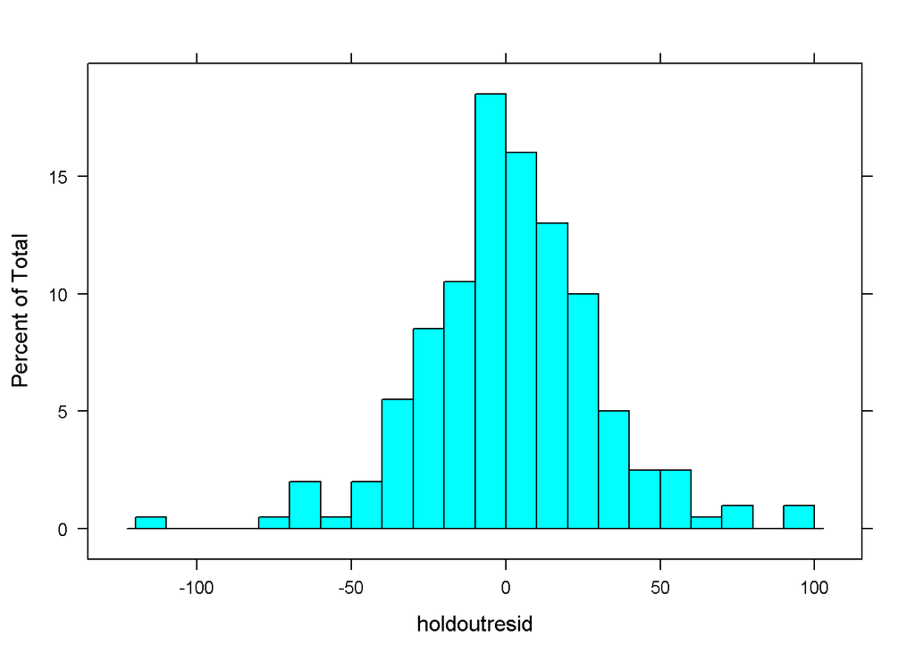

```r
histogram(holdoutresid, breaks=15)
```

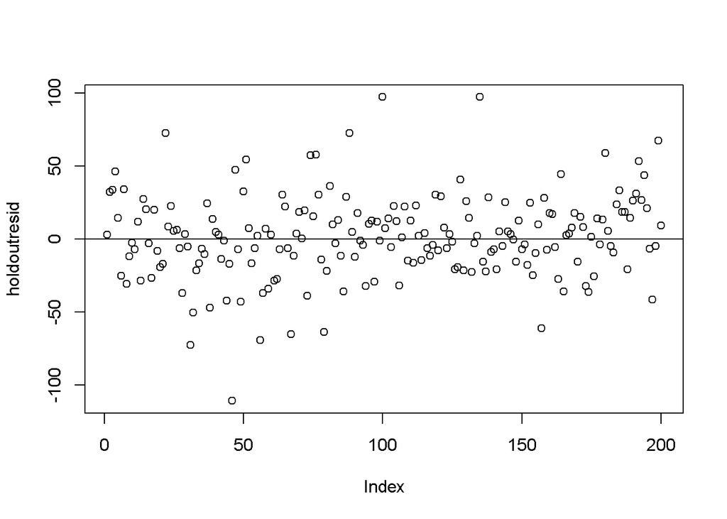

```r
plot(holdoutresid)
abline(0,0)
```

```r
corr = cor(AmesTest12$Price, fitPrice)
corr
```

```
## [1] 0.9349791
```

```r
summary(BasicModel)$r.squared-corr^2
```

```
## [1] -0.05895722
```

The cross validation test performed much better for the finalFancyModel than the basic model. It had a smaller standard deviation, higher correlation, and mean closer to zero for the holdout residuals data. moreover though the original model had reverse shrinkage, the finalFancyModel had shrinkage incredibly close to 0 at .003. While the BasicModel has an arguably more normal residual plot, the residual plot for the finalFancyModel is well within the bounds of normality.

** PART 9 **

```r
summary(finalFancyModel)
```

```
##
## Call:
## lm(formula = Price ~ LotFrontage + LotArea + factor(Quality) +
##     YearBuilt + ExteriorQ + BasementSF + GroundSF + KitchenQ +
##     Fireplaces + GarageSF + I(WoodDeckSF + OpenPorchSF + EnclosedPorchSF +
##     ScreenPorchSF), data = AllData3)
##
## Residuals:
##      Min       1Q   Median       3Q      Max
## -129.370  -14.210   -0.053   12.437  108.889
##
## Coefficients:
##                                                                 Estimate
## (Intercept)                                                   -7.504e+02
## LotFrontage                                                    1.037e-01
## LotArea                                                        5.319e-04
## factor(Quality)2                                               2.207e+01
## factor(Quality)3                                               5.442e+01
## factor(Quality)4                                               5.352e+01
## factor(Quality)5                                               5.798e+01
## factor(Quality)6                                               6.818e+01
## factor(Quality)7                                               8.275e+01
## factor(Quality)8                                               1.111e+02
## factor(Quality)9                                               9.212e+01
## factor(Quality)10                                              1.541e+02
## YearBuilt                                                      4.229e-01
## ExteriorQFa                                                   -6.145e+01
## ExteriorQGd                                                   -5.301e+01
## ExteriorQTA                                                   -5.697e+01
## BasementSF                                                     2.015e-02
## GroundSF                                                       3.961e-02
## KitchenQFa                                                    -5.683e+01
## KitchenQGd                                                    -4.206e+01
## KitchenQPo                                                    -4.200e+01
## KitchenQTA                                                    -4.800e+01
## Fireplaces                                                     1.071e+01
## GarageSF                                                       3.522e-02
## I(WoodDeckSF + OpenPorchSF + EnclosedPorchSF + ScreenPorchSF)  2.596e-02
##                                                               Std. Error
## (Intercept)                                                    9.722e+01
```

[output cut: 67 more lines]

```
## BasementSF                                                    1.29e-08 ***
## GroundSF                                                       < 2e-16 ***
## KitchenQFa                                                    1.79e-09 ***
## KitchenQGd                                                    2.85e-14 ***
## KitchenQPo                                                    0.098817 .
## KitchenQTA                                                    9.96e-16 ***
## Fireplaces                                                    7.59e-08 ***
## GarageSF                                                      1.78e-08 ***
## I(WoodDeckSF + OpenPorchSF + EnclosedPorchSF + ScreenPorchSF) 0.000148 ***
## ---
## Signif. codes:  0 '***' 0.001 '**' 0.01 '*' 0.05 '.' 0.1 ' ' 1
##
## Residual standard error: 24.63 on 575 degrees of freedom
## Multiple R-squared:  0.8983, Adjusted R-squared:  0.8941
## F-statistic: 211.6 on 24 and 575 DF,  p-value: < 2.2e-16
```

```r
HouseDataFrame = data.frame(ExteriorQ="Gd",KitchenQ="Gd",Quality=7,WoodDeckSF=0,OpenPorchSF=274,EnclosedPorchSF=0,ScreenPorchSF=0,LotFrontage=90,LotArea=11060,YearBuilt=1995,BasementSF=1150,GroundSF=2314,GarageSF=502,Fireplaces=1)

predict.lm(finalFancyModel, HouseDataFrame, interval="prediction", level=.95)
```

```
##        fit      lwr      upr
## 1 246.4451 197.6612 295.2291
```

KitchenQ was not specified in the description of the house in Part 9. Because overall quality was good and exterior quality was good, we made KitchenQ good.

** The fit price given by the model for this house is $246,445.10 Based on the prediction interval, we are 95% confident that the true price of this house lies between $197,661.20 and $295,229.10 **